# Draft ERLP findings - ASPs

### Responses

14 questions were posed as part of this exercise. These are summarized below.

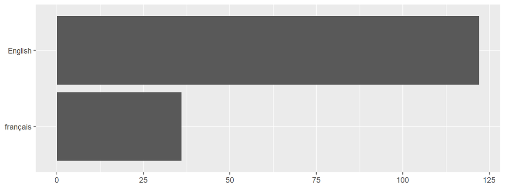

All responses

| Language | Responses | % |
| --- | --- | --- |
| English | 122 | 77% |
| français | 36 | 23% |

##### 2. Using this definition, approximately what percentage of your ASP examination work is in remote locations?

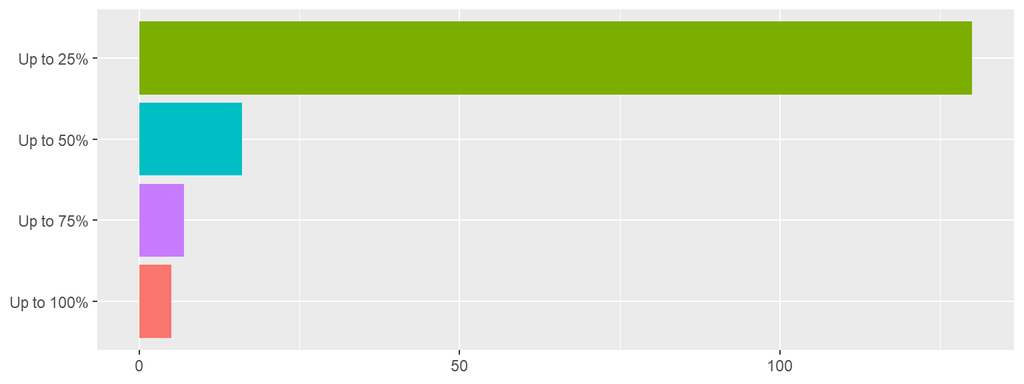

All responses

| Percent work remote | Responses | % |
| --- | --- | --- |
| Up to 25% | 130 | 82% |
| Up to 50% | 16 | 10% |
| Up to 75% | 7 | 4% |
| Up to 100% | 5 | 3% |

##### 3. Approximately what percentage of your examinations performed in remote locations are on devices with mandatory examination periods?

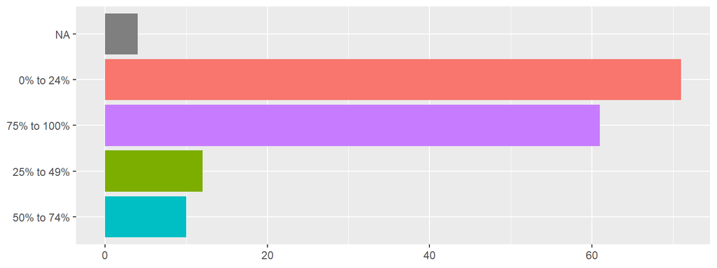

All responses

| Percent work remote mandatory | Responses | % |
| --- | --- | --- |
| 75% to 100% | 61 | 39% |
| 50% to 74% | 10 | 6% |
| 25% to 49% | 12 | 8% |
| 0% to 24% | 71 | 45% |
| NA | 4 | 3% |

##### 4. What are the cost differences between local examinations and an examination performed in a remote location?

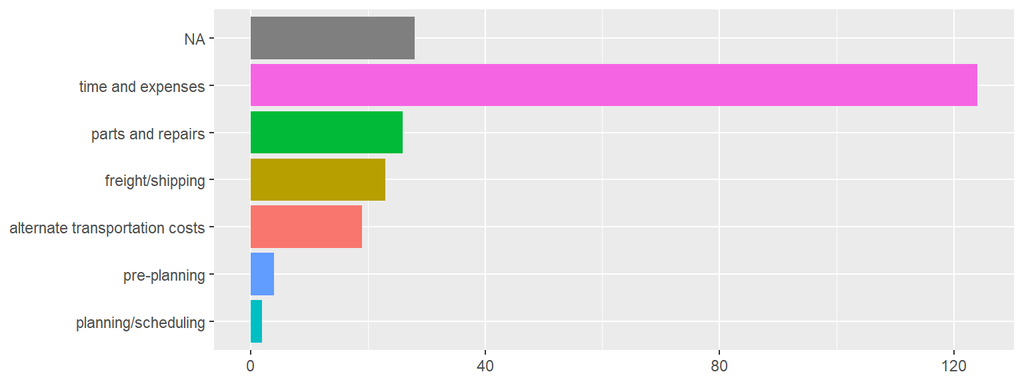

All responses

| Costs | Responses | % |
| --- | --- | --- |
| time and expenses | 124 | 55% |
| NA | 28 | 12% |
| parts and repairs | 26 | 12% |
| freight/shipping | 23 | 10% |
| alternate transportation costs | 19 | 8% |
| pre-planning | 4 | 2% |
| planning/scheduling | 2 | 1% |

##### 5. Are there any aspects of performing examinations in remote locations that lead to problems with scheduling or performing these examinations?

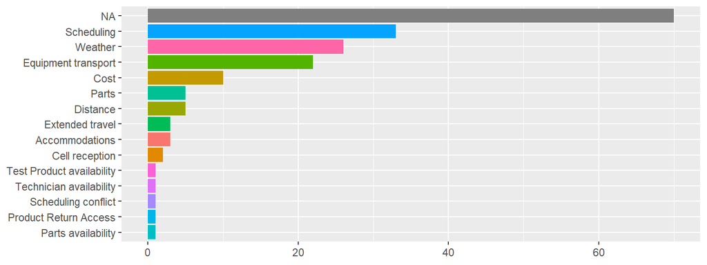

All responses

| Problems Scheduling | Responses | % |
| --- | --- | --- |
| NA | 70 | 38% |
| Scheduling | 33 | 18% |
| Weather | 26 | 14% |
| Equipment transport | 22 | 12% |
| Cost | 10 | 5% |
| Distance | 5 | 3% |
| Parts | 5 | 3% |
| Accommodations | 3 | 2% |
| Extended travel | 3 | 2% |
| Cell reception | 2 | 1% |
| Parts availability | 1 | 1% |
| Product Return Access | 1 | 1% |
| Scheduling conflict | 1 | 1% |
| Technician availability | 1 | 1% |
| Test Product availability | 1 | 1% |

##### 6. Have you refused or been unable to perform a requested examination in a remote area?

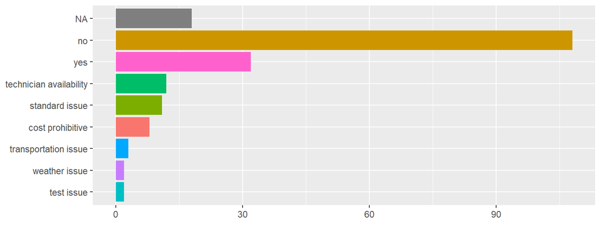

All responses

| Refused | Responses | % |
| --- | --- | --- |
| no | 108 | 55% |
| yes | 32 | 16% |
| NA | 18 | 9% |
| technician availability | 12 | 6% |
| standard issue | 11 | 6% |
| cost prohibitive | 8 | 4% |
| transportation issue | 3 | 2% |
| test issue | 2 | 1% |
| weather issue | 2 | 1% |

##### 7. Do you typically perform repairs required to ensure compliance at the time of examination?

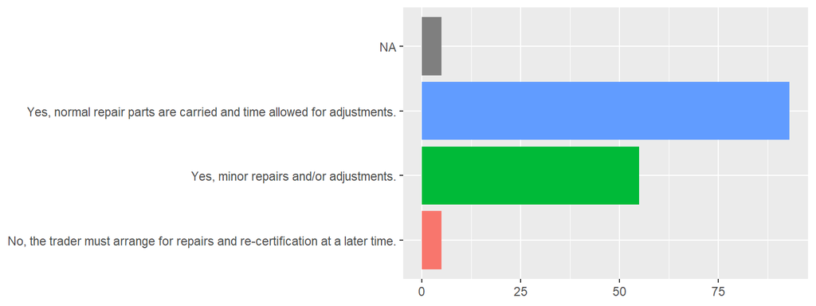

All responses

| Perform repairs | Responses | % |
| --- | --- | --- |
| Yes, normal repair parts are carried and time allowed for adjustments. | 93 | 59% |
| Yes, minor repairs and/or adjustments. | 55 | 35% |
| No, the trader must arrange for repairs and re-certification at a later time. | 5 | 3% |
| NA | 5 | 3% |

##### 8. How are requests for examinations in remote areas initiated?

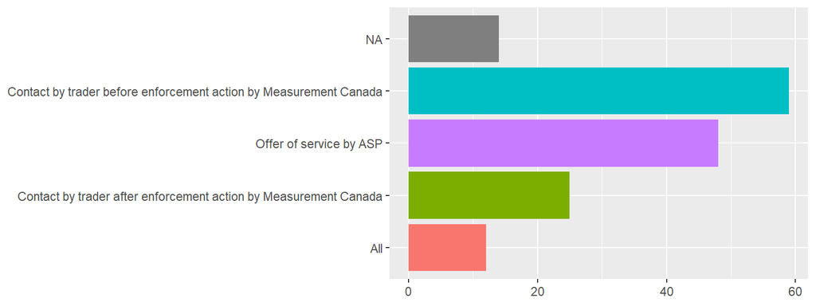

All responses

| Requests initiated | Responses | % |
| --- | --- | --- |
| Contact by trader before enforcement action by Measurement Canada | 59 | 37% |
| Offer of service by ASP | 48 | 30% |
| Contact by trader after enforcement action by Measurement Canada | 25 | 16% |
| NA | 14 | 9% |
| All | 12 | 8% |

##### 9. For devices with mandatory examination periods, when are these examinations typically scheduled?

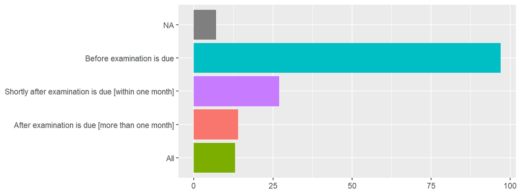

All responses

| Mandatory scheduled | Responses | % |
| --- | --- | --- |
| Before examination is due | 97 | 61% |
| Shortly after examination is due [within one month] | 27 | 17% |
| After examination is due [more than one month] | 14 | 9% |
| All | 13 | 8% |
| NA | 7 | 4% |

##### 10. When working in remote locations, do your technicians communicate/offer service to other businesses found to have overdue devices ?

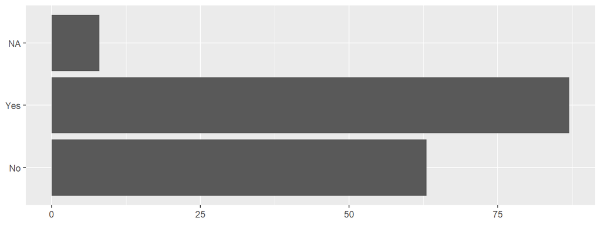

All responses

| Offer service | Responses | % |
| --- | --- | --- |
| Yes | 87 | 55% |
| No | 63 | 40% |
| NA | 8 | 5% |

##### 11. Is there anything traders in remote areas can do to expedite the scheduling or performing of examinations or to reduce the costs (sharing of travel costs, timing, etc.)?

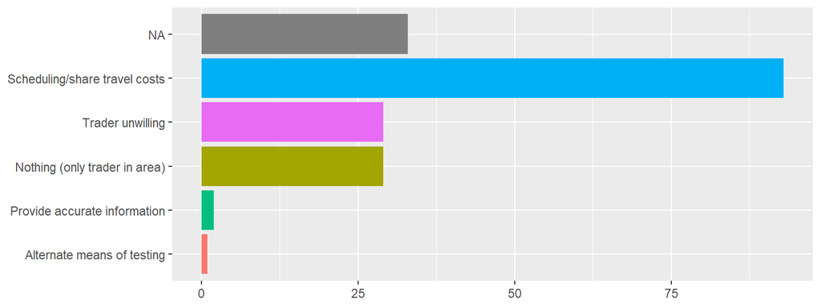

All responses

| Trader improve | Responses | % |
| --- | --- | --- |
| Scheduling/share travel costs | 93 | 50% |
| NA | 33 | 18% |
| Nothing (only trader in area) | 29 | 16% |
| Trader unwilling | 29 | 16% |
| Provide accurate information | 2 | 1% |
| Alternate means of testing | 1 | 1% |

##### 12. Is there anything Measurement Canada can do to facilitate the scheduling or performing of examinations by ASPs in remote locations (joint inspections, sharing of standards, allow more bench testing, etc.)?

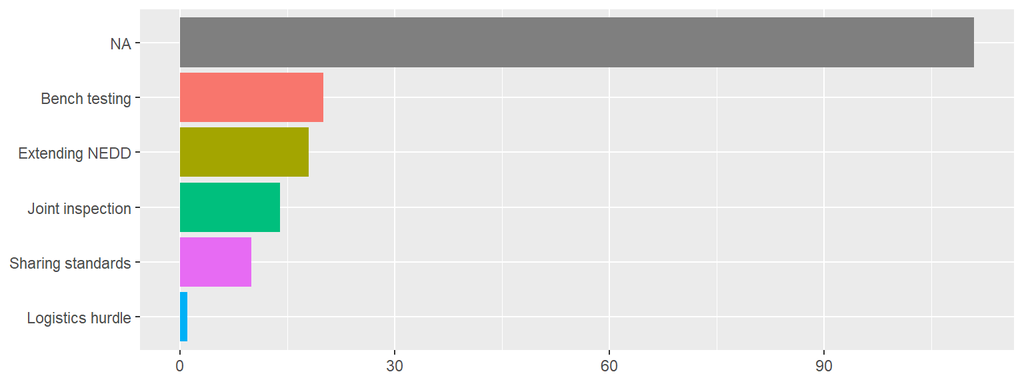

All responses

| MC improve | Responses | % |
| --- | --- | --- |
| NA | 111 | 64% |
| Bench testing | 20 | 11% |
| Extending NEDD | 18 | 10% |
| Joint inspection | 14 | 8% |
| Sharing standards | 10 | 6% |
| Logistics hurdle | 1 | 1% |

##### 13. If devices could be examined at alternate locations - ASP’s shop, location central to traders, etc., do you foresee any particular issues with performing these types of examinations (explain)?

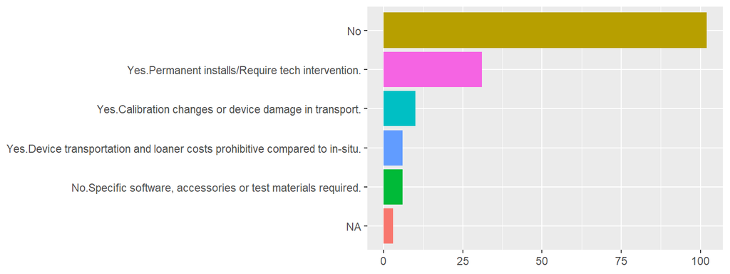

Simplified to show yes/no only

| yes | no |
| --- | --- |
| 47 | 111 |

All responses

| Alternate locations | Responses | % |
| --- | --- | --- |
| No | 102 | 65% |
| Yes.Permanent installs/Require tech intervention. | 31 | 20% |
| Yes.Calibration changes or device damage in transport. | 10 | 6% |
| No.Specific software, accessories or test materials required. | 6 | 4% |
| Yes.Device transportation and loaner costs prohibitive compared to in-situ. | 6 | 4% |
| NA | 3 | 2% |

##### 14. Can someone from Measurement Canada contact you regarding the feedback you’ve provided?

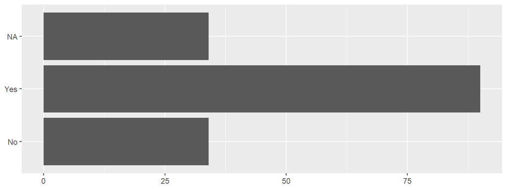

All responses

| Contact | Responses | % |
| --- | --- | --- |
| Yes | 90 | 57% |
| No | 34 | 22% |
| NA | 34 | 22% |